# Intro to Machine Learning

Types, Tasks, Terminology

# Introduction to Machine Learning

## What is What?

- Artificial Intelligence (AI),
- Machine Learning,
- Deep Learning
- Big Data

## What is What?

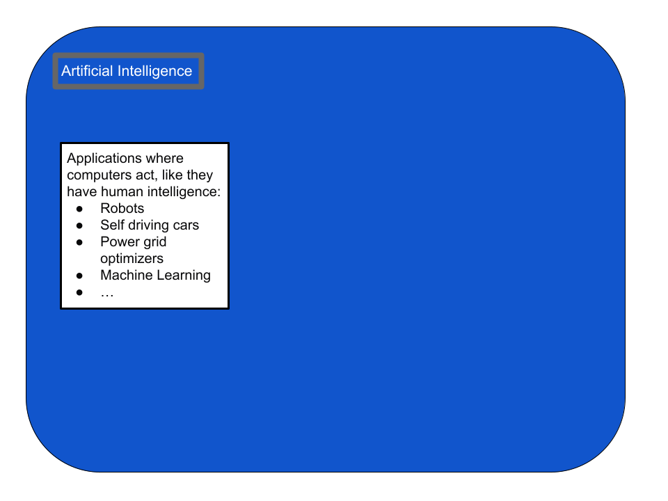

Types of AI

## What is What?

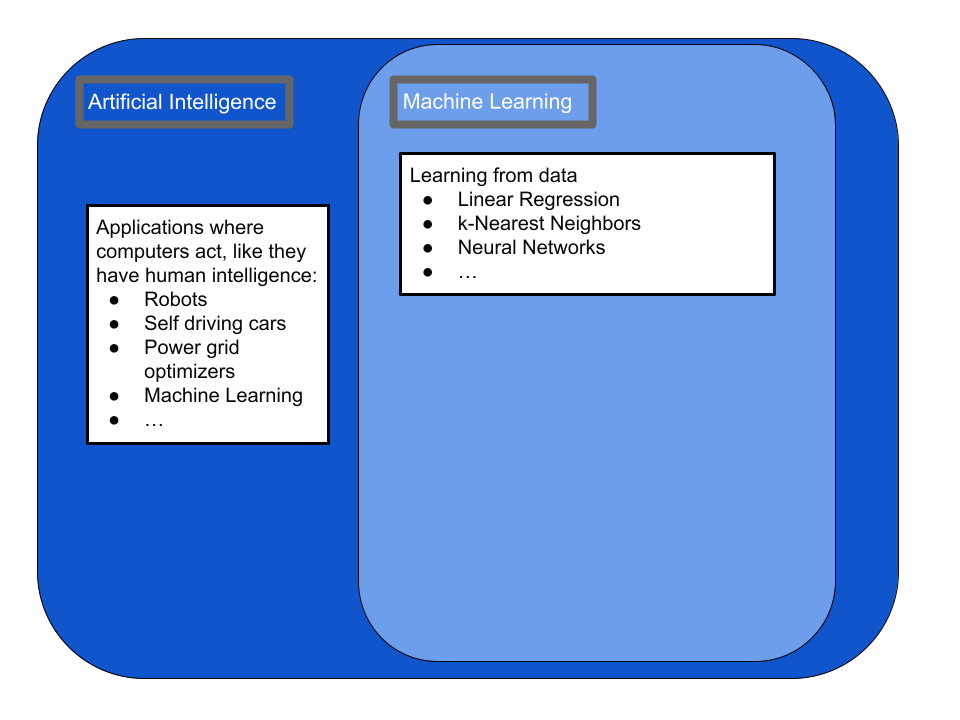

Types of AI

## What is What?

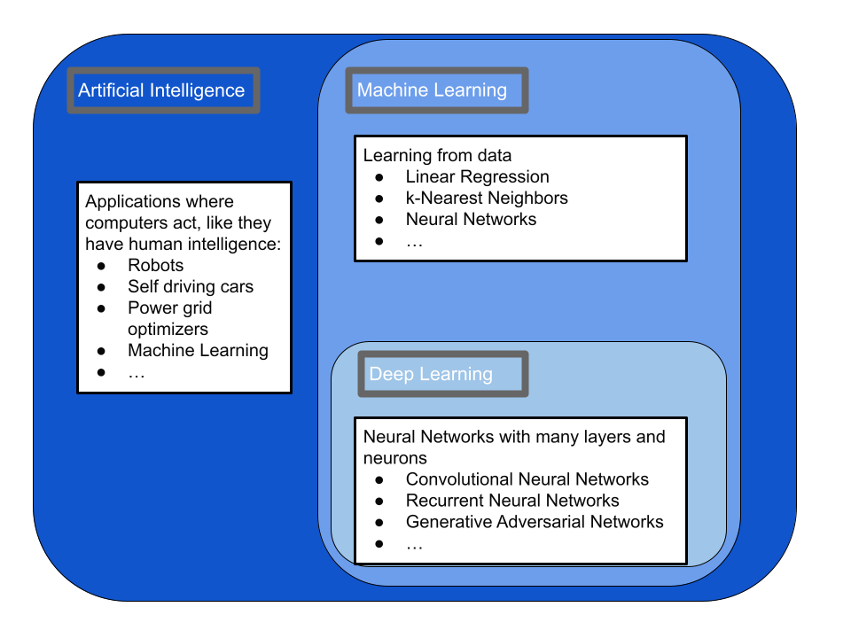

Types of AI

## What About Big Data

- Big Data is not a category of learning. It is a category of data!!!
- Two common definitions
  - Laymen: Many records (thousands?, millions?, billions?)
  - Experts: So many records that they do not fit in the memory of one computer.
    - At least billions of records.
    - Requires distributed computing.

## Three Applications of Machine Learning

- Regression
- Classification
- Cluster

## Three Applications of Machine Learning

- Regression
  - Outcome variable is continuous
  - We try to predict a numerical value
- Classification
- Cluster

## Three Applications of Machine Learning

- Regression
- Classification
- Cluster

## Three Applications of Machine Learning

- Regression
- Classification
  - Outcome variable is categorial
  - Most of the times 2 categories such as:
    - Yes/No
    - Red Wine/White Wine
    - True/False
    - often represented as dummies: 1/0
  - Sometimes more than two catogories (ordered or unordered):
    - good, fair, bad (ordered)
    - red, blue, green (unordered)
    - strongly agree, agree, disagree, strongly disagree (ordered)
- Cluster

## Three Applications of Machine Learning

- Regression
- Classification
- Cluster

## Three Applications of Machine Learning

- Regression
- Classification
- Cluster
  - Sorting observations into a number of groups based on feature variables.
  - Groups are as homogenous inside as possible.
  - Groups are as diverse between groups (when comparing groups)

## Three Applications of Machine Learning

- Regression
- Classification
- Cluster

## Terminolgy

First 3 Observations (records) of the Housing Dataset (to predict house prices)

```r
library(rio);library(tidyverse)
DataHousing =
  import("https://lange-analytics.com/AIBook/Data/HousingData.csv") %>%
  select(Price=price, Sqft=sqft_living, Bedrooms=bedrooms,Waterfront=waterfront)
print(DataHousing[1:3,])
```

```
##    Price Sqft Bedrooms Waterfront
## 1 221900 1180        3         no
## 2 538000 2570        3         no
## 3 180000  770        2         no
```

Tidy data:

- Observations (synonym: records) are in the rows.
- Variables (synonym: features) are in the columns.
- Variable names (column names) are in the first row.
- Data are in individual cells (and they form vectors; column names can be interpreted as vector names).

## Terminolgy

### Main

First 3 Observations (records) of the Housing Dataset (predict house prices)

```r
library(rio);library(tidyverse)
DataHousing =
  import("https://lange-analytics.com/AIBook/Data/HousingData.csv") %>%
  select(Price=price, Sqft=sqft_living, Bedrooms=bedrooms,Waterfront=waterfront)
print(DataHousing[1:3,])
```

```
##    Price Sqft Bedrooms Waterfront
## 1 221900 1180        3         no
## 2 538000 2570        3         no
## 3 180000  770        2         no
```

- **Outcome Variable**: The variables that is the outcome of the prediction ($Price$)
- **Predictor Variables**: The variables that **predict** an outcome ($Sqft$, $Bedrooms$, $Waterfront$)
- **Example linear regression:** $Price=\beta_1 \cdot Sqft+ \beta_2 \cdot Bedrooms +\beta_3 \cdot Waterfront+\beta_4$

### Synonyms

- **Synonyms for Outcome Variable:**
  - Response variable (it responds to the predictors)
  - Dependent variable (it is dependent on the predictors)
  - Endogenous variable (it is dependent on the predictors)
- **Synonyms for Predictor Variables:**
  - Explanatory variables variables (they explain the outcome)
  - Independent variables (they are chosen independently to see how the impact the outcome)
  - Exogenous variable (they are chosen independently to see how the impact the outcome)

## Why Using R for Machine Learning?